# Covid-19 - SMSD

#### Goal

Build up a useful model in order to predict response variable Y starting from data provided.

- response variable: number of new positives
- data: Covid-19 spreading outbreak from the official website of Protezione Civile

#### Dataset

Load dataset.

Read data we are interested in, then those that are relative to the following couple of parameters:

- regione: Sicilia
- data: 1st October 2020 to 1st February 2021

#### Quality of the data

Check for missing values in the data frame

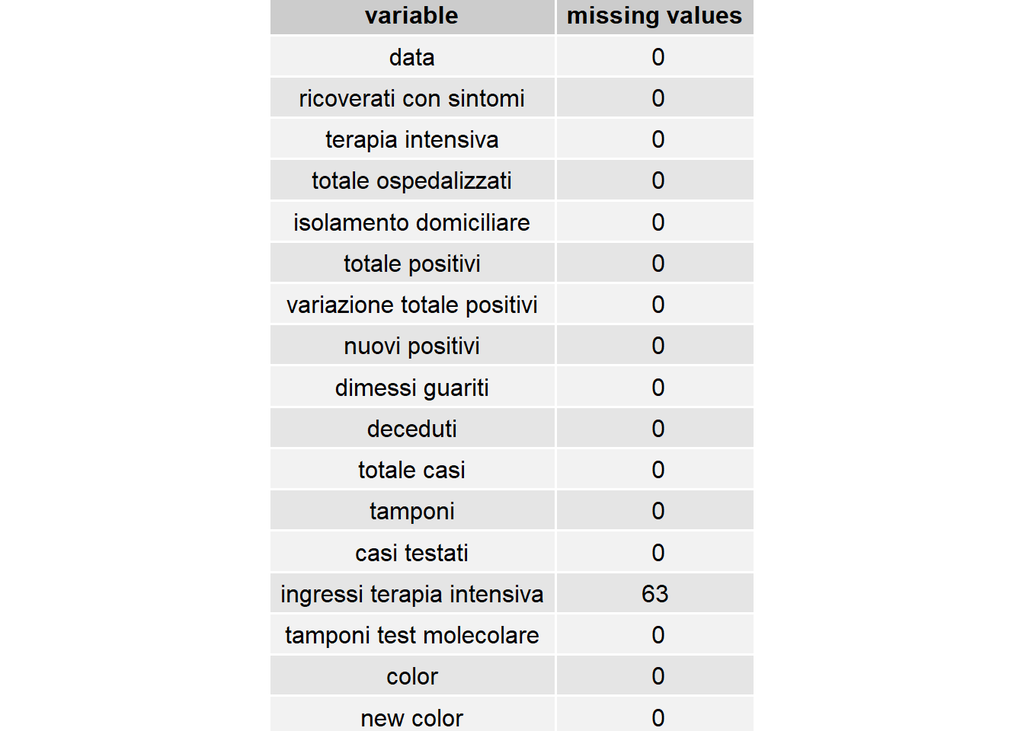

Missing value are about the admission to the ICU and for this reason that value has been removed and it has been considered the number of ICU per day.

#### Clean dataset

Get rid of redundant and not useful variables, substitute or replace missing values and finally check for any kinf of relationship between variables.

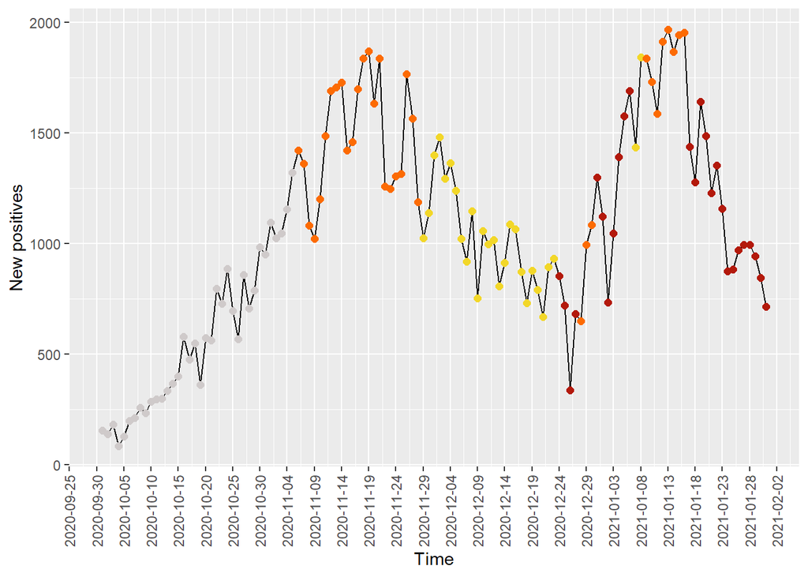

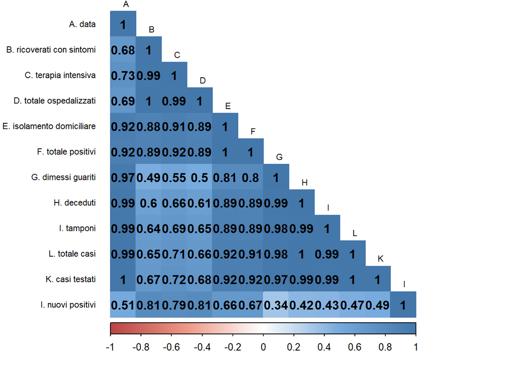

We can see there are many variables which are highly related, though this relationship can be due to the fact that they are not independent. While for others variables we observe a poor correlation while we would have expected something different, for example for the number of swabs carried out. For this reason new variables were introduced for those values which account for the total amount of cases since the beginning of the pandemic.

- nuovi_tamponi: swabs carried out daily (tamponi current day - tamponi predious day) [by the 15/01 were counted also the antigenic tests]
- nuovi_decessi: daily deaths (deceduti current day - deceduti previous day)

#### Perform some explanatory analysis of the data

Then a new correlation plot is made to show which are the most highly correlated variables.

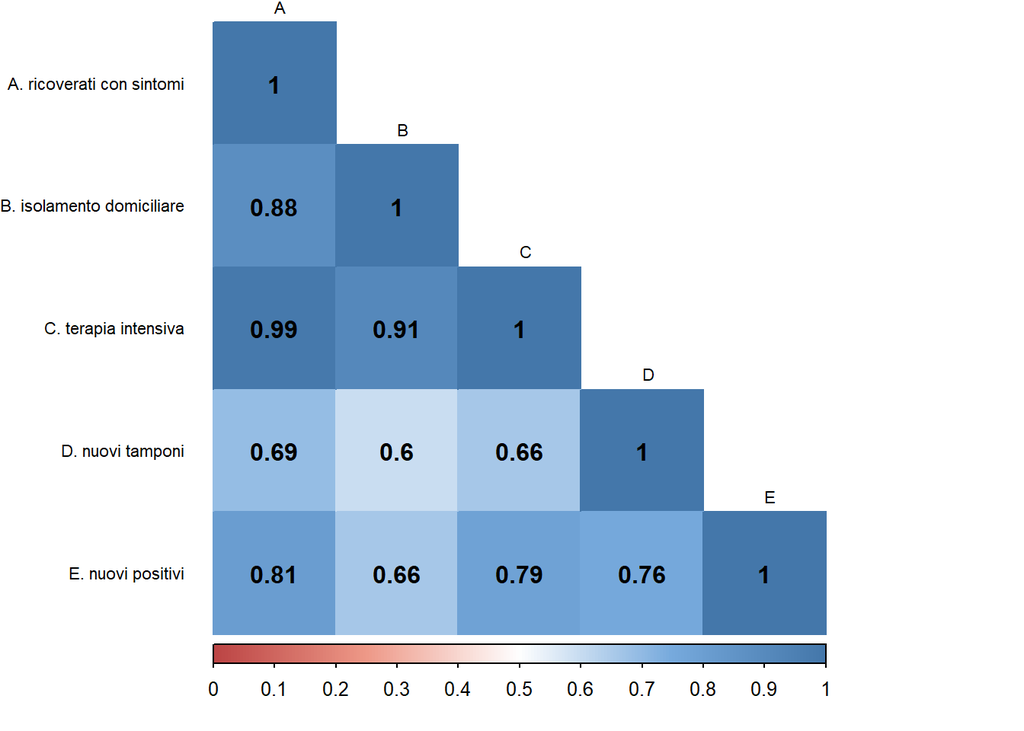

Further investigate the correlations found between each pair of variables

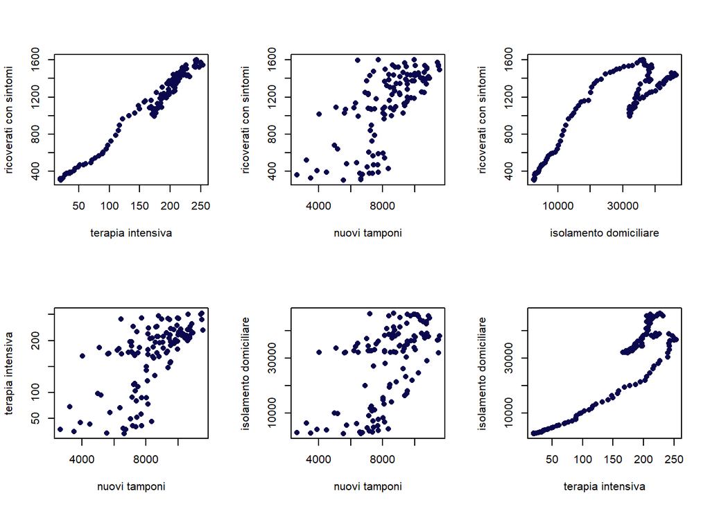

The following plot shows the trends of previous variable through all the time period considered, it can be seen how it is almost the same for each of them, exept for the number of swabs.

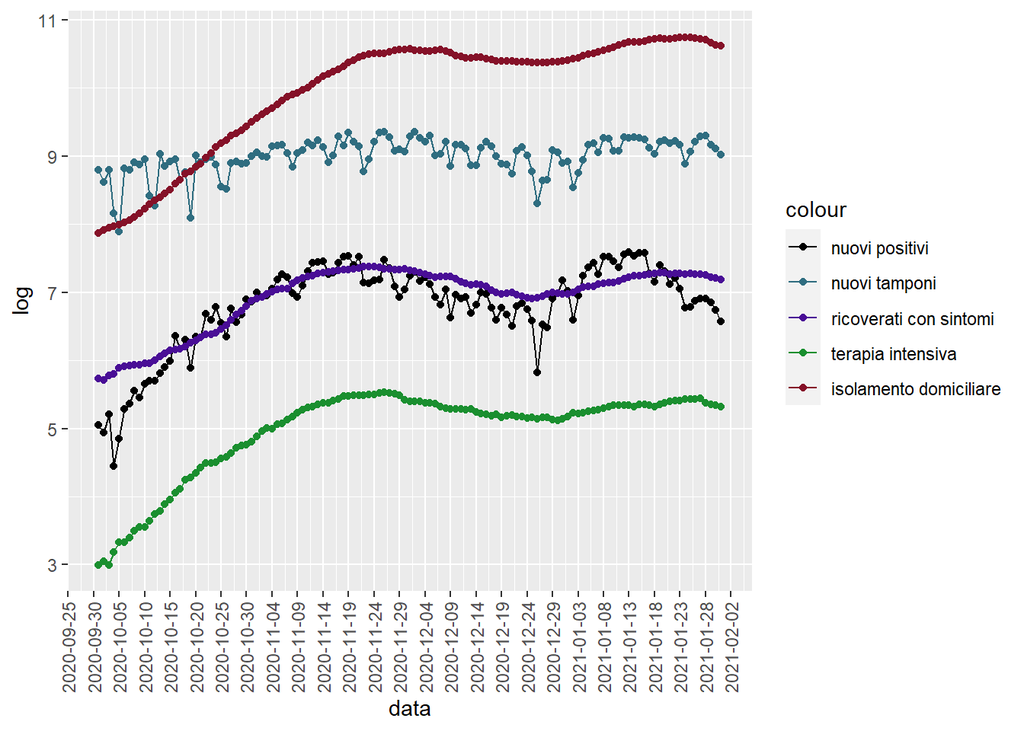

Previous chosen covariates were part of the given dataset, now we investigate possible relationships with information which is not part of our dataset. The first covariate which has been considered and added is related to the restrictions to which the region was subjected in the period considered. These restrictions are of 4 different levels, which are the 4 possible regional colors: white, yellow, orange, red.

- See how response variable changes wrt to region colors:

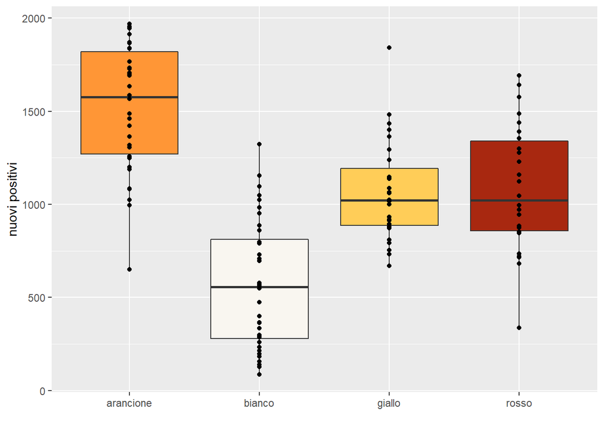

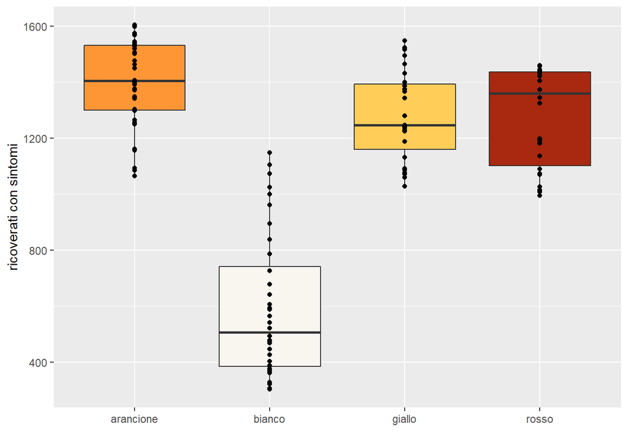

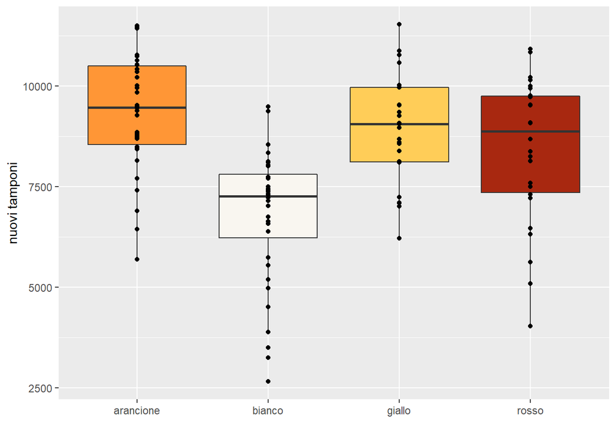

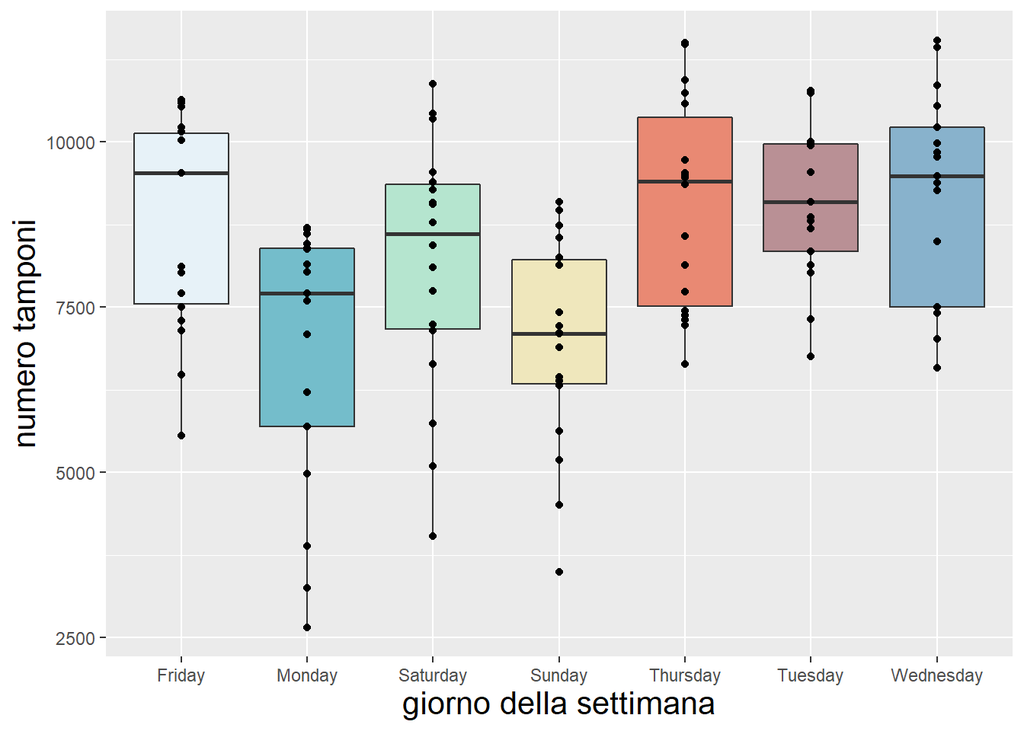

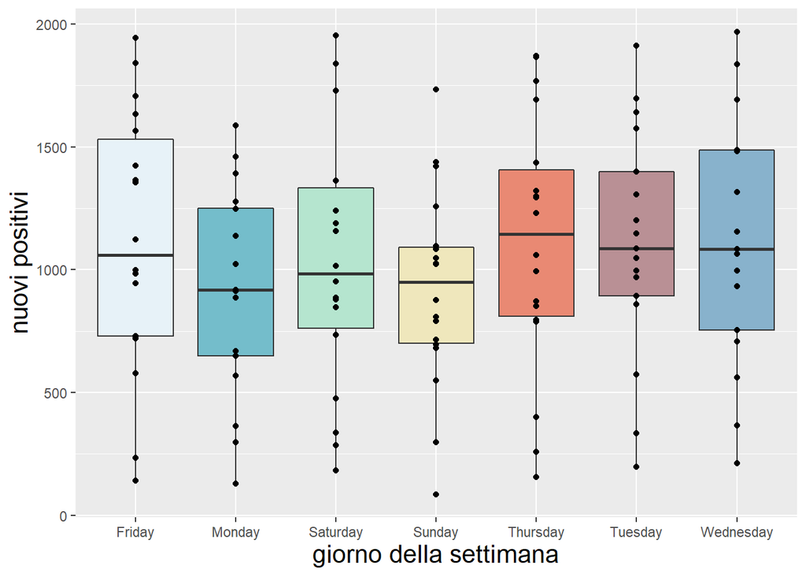

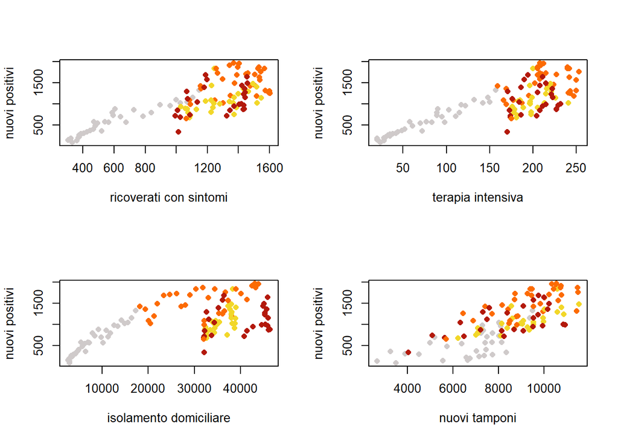

## Building models

We start building our model looking at the relationship between our response variable and its highest correlated predictor (which is given by people hospitalized with symptoms, maybe because the highest the number of people hospitalized, the higher the contagiousness and as a consequence the higher the number of new positives).

### Linear models

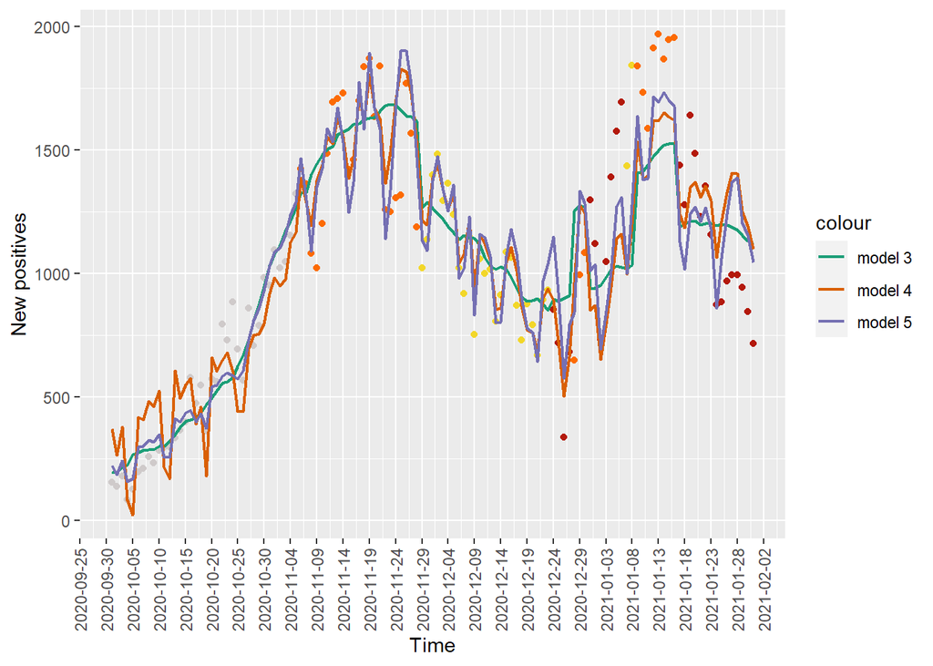

### Generalized linear models

#### Poisson distirbution

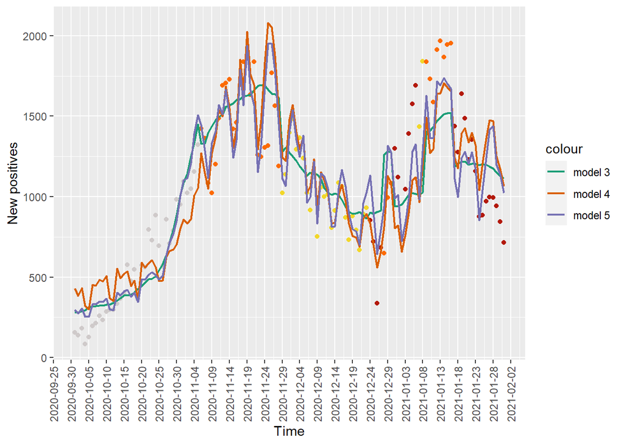

```
##          df       AIC
## glm_mod1  2 11485.561
## glm_mod2  5 10264.652
## glm_mod3  8  8549.686
## glm_mod4  6  8298.537
## glm_mod5 12  6149.989
```

Check residual plot with respect to region color:

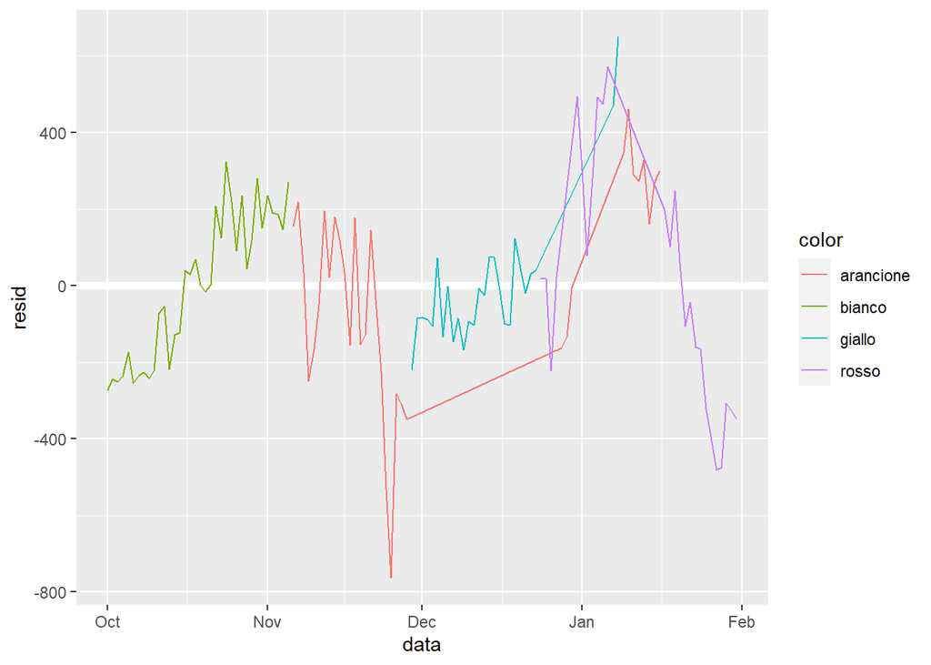

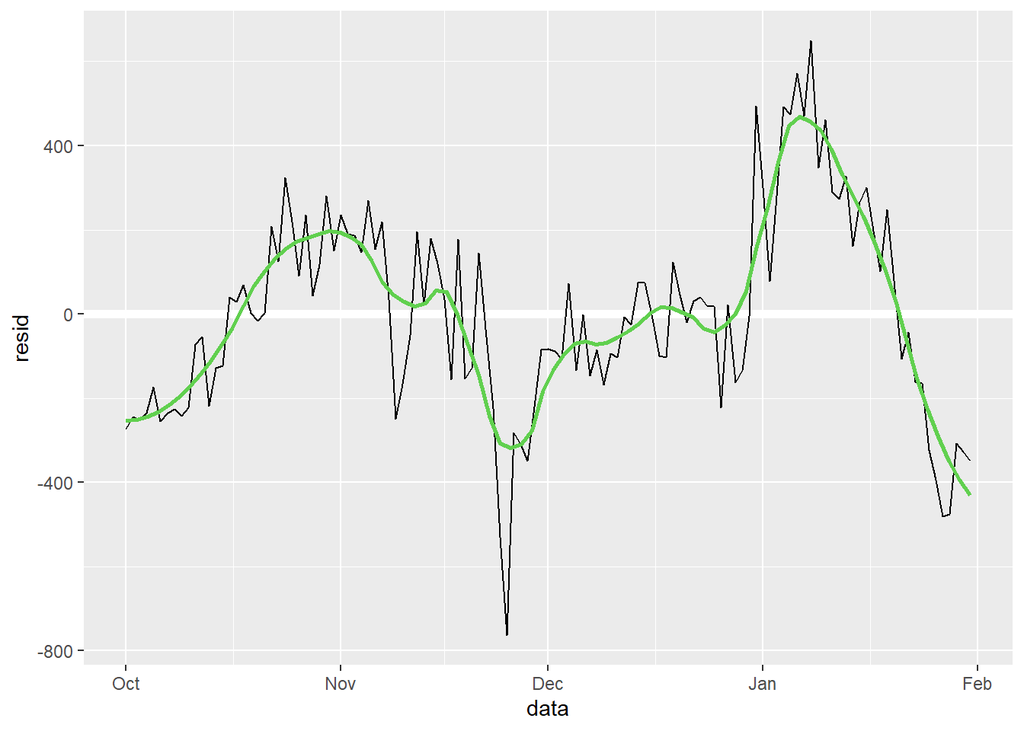

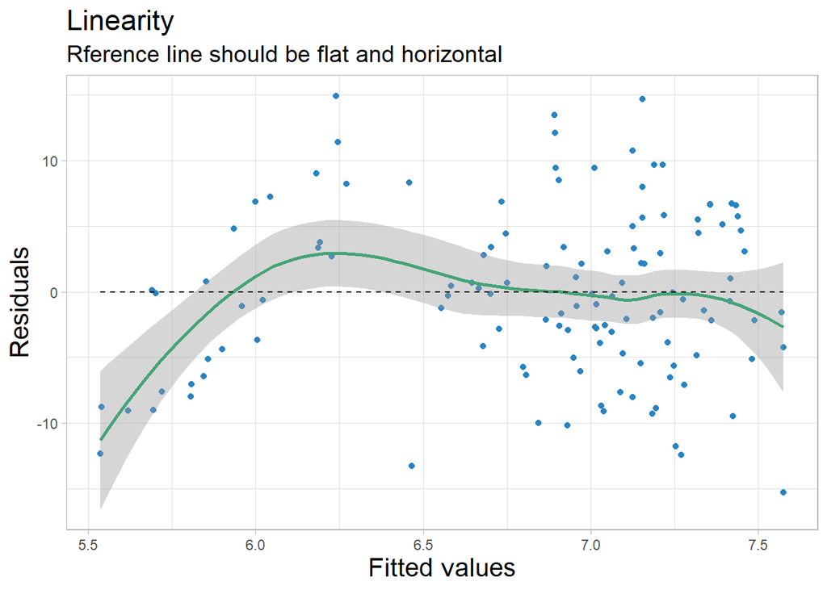

#### GLM with negative binomial

```
FALSE         df      AIC
FALSE nglmod1  3 1754.076
FALSE nglmod2  6 1749.925
FALSE nglmod3  9 1724.282
FALSE nglmod4  7 1731.239
```

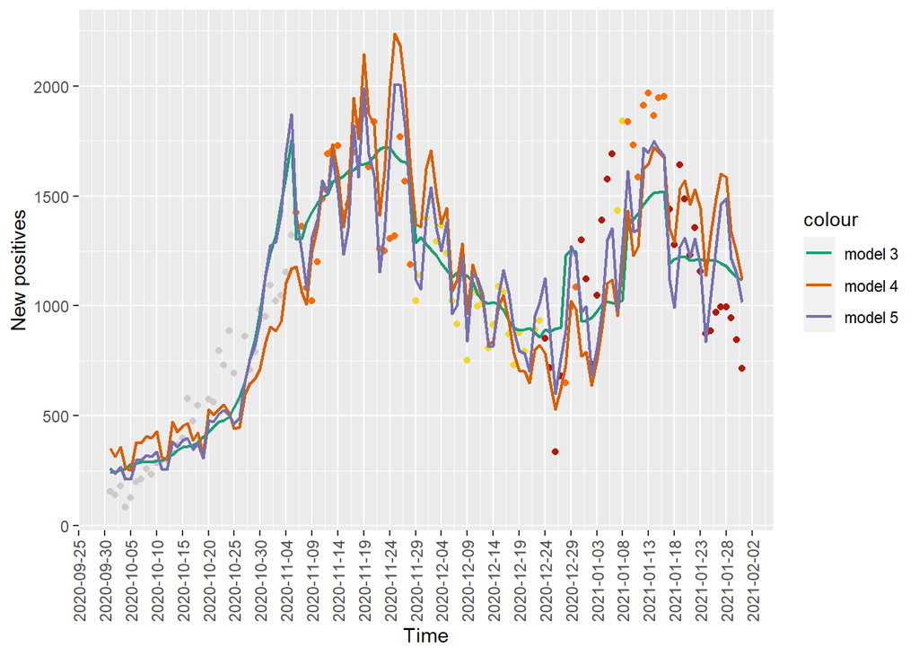

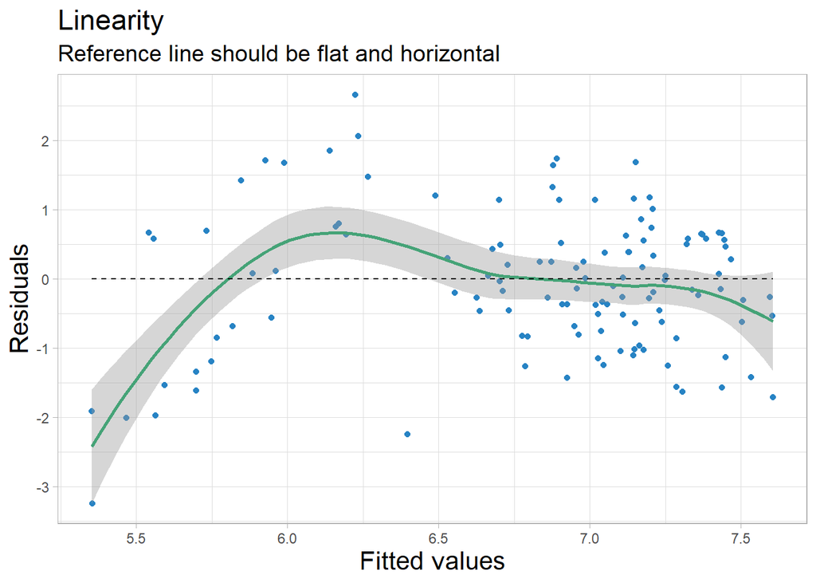

# Performance tab

## LOESS

```
## Call:
## loess(formula = nuovi_positivi ~ terapia_intensiva + ricoverati_con_sintomi_prev +
##     nuovi_tamponi_pcr, data = df)
##
## Number of Observations: 123
## Equivalent Number of Parameters: 14.59
## Residual Standard Error: 268.8
## Trace of smoother matrix: 17.77  (exact)
##
## Control settings:
##   span     :  0.75
##   degree   :  2
##   family   :  gaussian
##   surface  :  interpolate      cell = 0.2
##   normalize:  TRUE
##  parametric:  FALSE FALSE FALSE
## drop.square:  FALSE FALSE FALSE
```

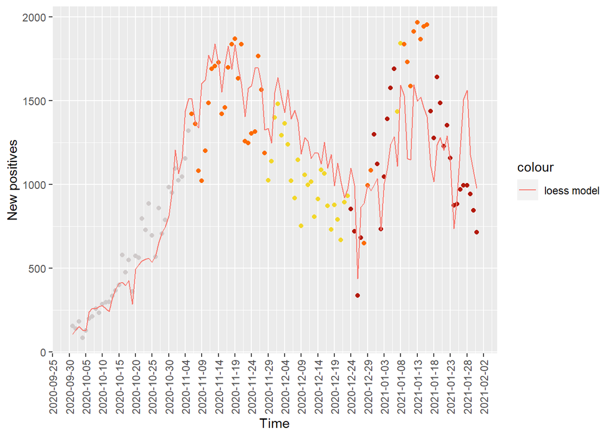

# Plot response on covariates

### With respect to best glm model:

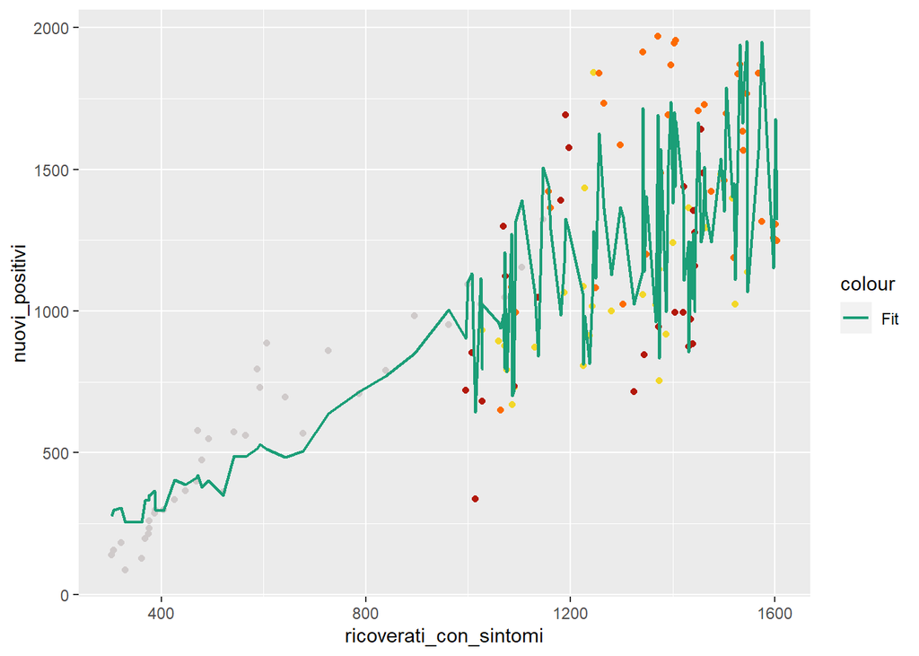

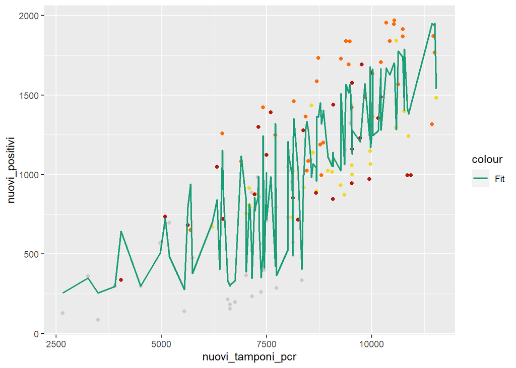

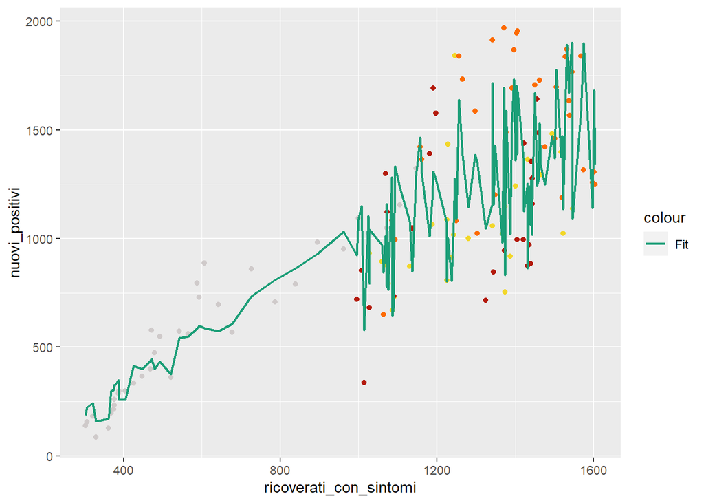

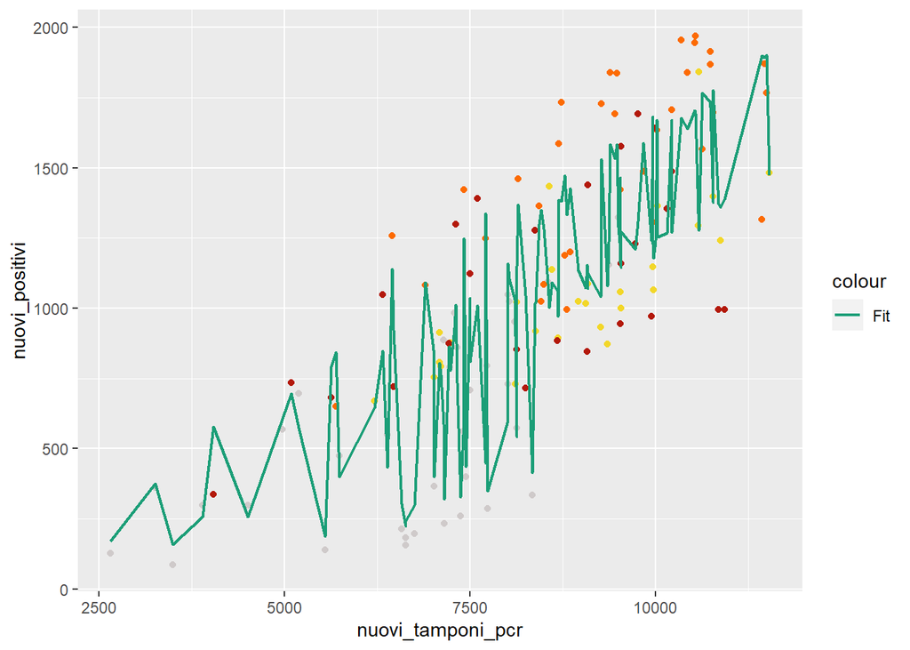

## GAM

Since the best glm model is the last one (from the AIC ), I will try to build a GAM using the same covariates.

[output not shown]

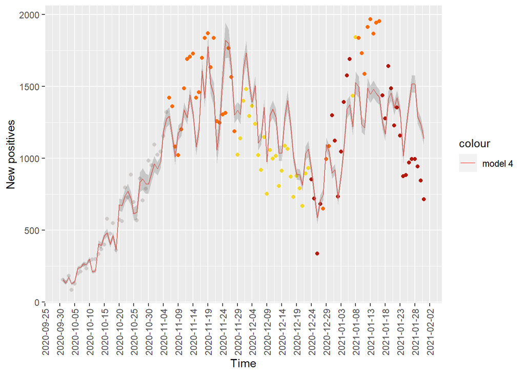

Predictions using previous gam model are the following:

```
## [1] 51.62441
```

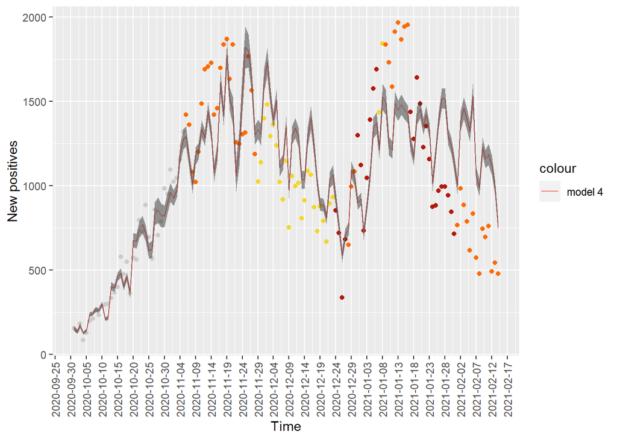

# Predictions

We investigate prediction accuracy testing previous models on the next 15 days of Febraury.

### Linear model

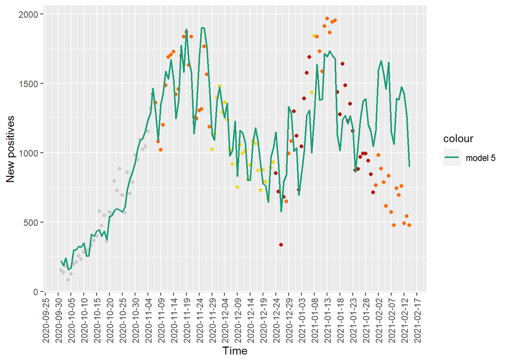

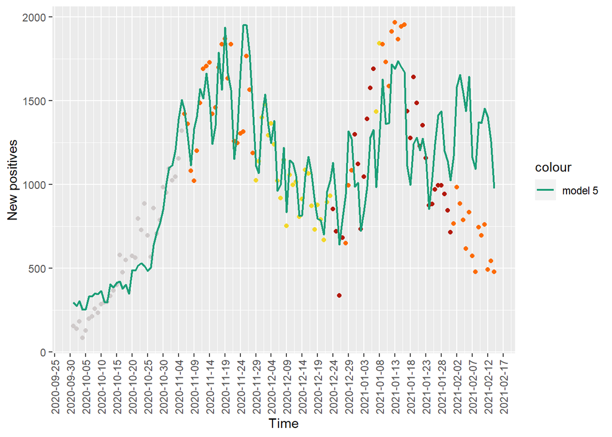

```
##      model      smape
## [1,] "lm_mod5"  "0.332563922160804"
## [2,] "glm_mod5" "0.330862108131558"
## [3,] "nglmod5"  "0.353784860164653"
## [4,] "gam_mod1" "0.464364775572646"
```

# NEW COLOR

All the models previously considered overestimate the number of new positives on the first two weeks of Febraury. This behaviour might be due to the gap between the variable color and the actual level of restrictions. To handle this issue a new numerical variable (livello_di_restrizioni) has been added.

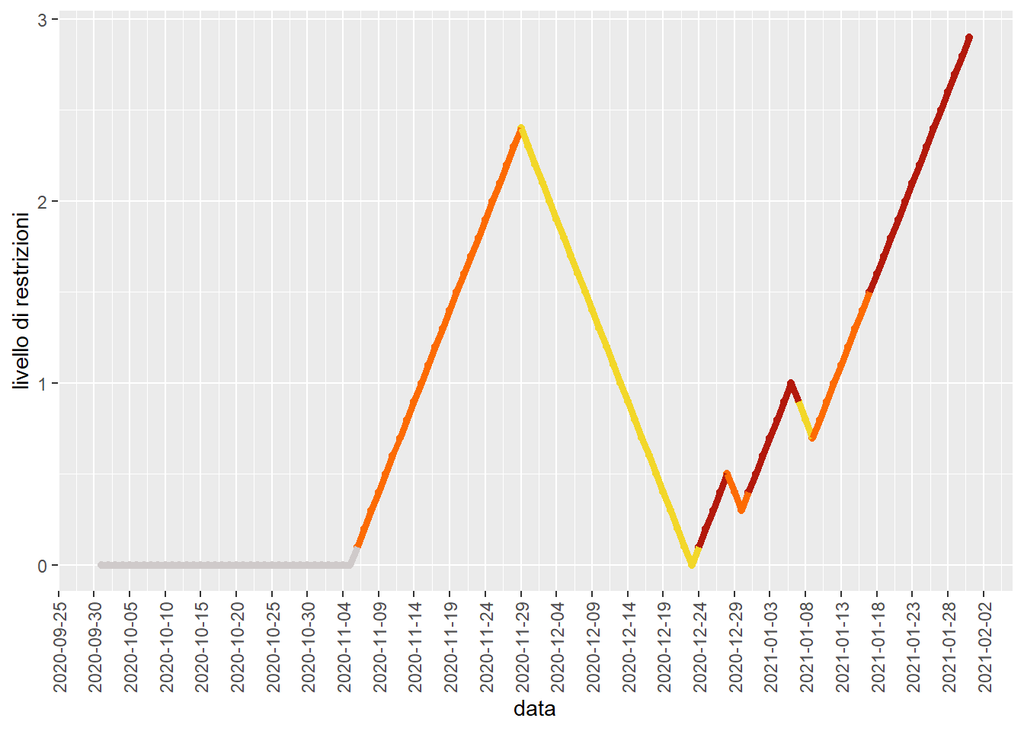

Let’s see how our previous model change adding new color:

- Linear model

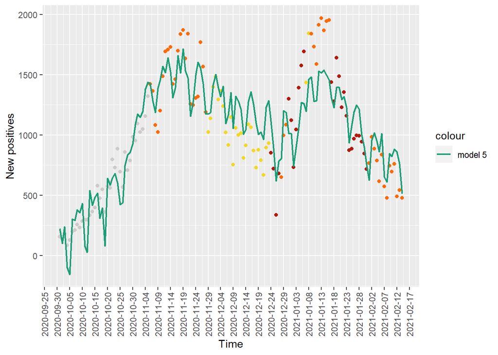

- Generalized linear model - Poisson

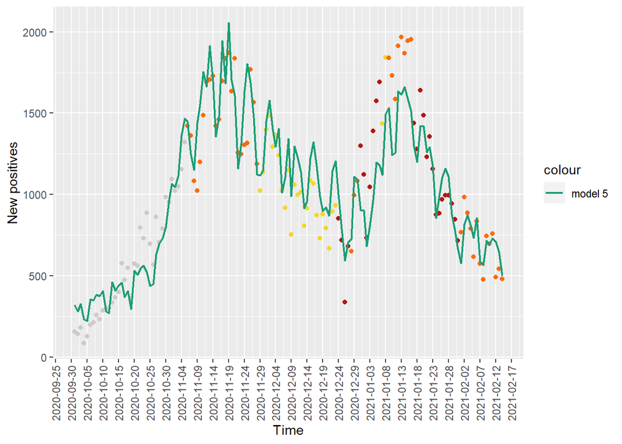

- Generalized linear model - Ngeative Binomial

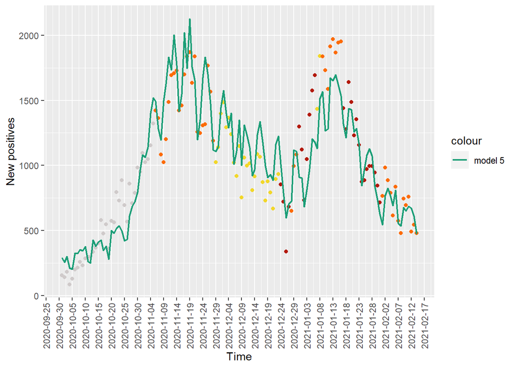

- Generalized additive models